# ggutils: 更好用的 ggplot2 工具箱

智能轴标签、聚类树、环形布局与螺旋坐标

> English version: `vignette("ggutils-en")`

# ggutils 是什么

`ggutils` 是 `ggplot2` 的扩展包，专管**轴旁边那点事**。

`ggplot2` 把面板、刻度、图例都画得很好，但碰到下面这几种情况就得自己写 `theme()`、 `gtable`，或者干脆放弃：分类轴上有 50 个、200 个水平，标签挤成一团；想在离散轴旁边挂一棵 聚类树，还得让树的叶子和标签顺序对得上；分面之后希望每个面板按自己的数据范围画刻度。

`ggutils` 把这些收进几个 `guide_*()`、`scale_*()`、`facet_*()` 里，写法仍然是 `ggplot2` 的写法——图层不动、`theme()` 不动，只在轴和分面这一层加东西。

| 你遇到的事 | 用什么 |
| --- | --- |
| 分类标签挤在一起，只想挑几个显示 | `guide_axis_smart()`，配合 `n =` / `which =` / `nrow =` |
| 挑出来的标签要连回各自的刻度 | `guide_axis_smart()` 的引导线（`connection_style`） |
| 离散轴旁边挂聚类树，且树与标签同序 | `guide_axis_cluster()` / `scale_x_cluster()` / `scale_y_cluster()` |
| 分面后每个面板要自己的刻度、自己的轴、自己的一棵树 | `facet_gridn()` |
| 几百个标签排不进一条直线 | `coord_spiral()` / `scale_x_spiral_axis()` |
| 树被分面条带挤掉了 | `strip_cluster()` |
| 只要排布算法本身，自己拿去画别的 | `box_arrange()` / `smart_align()` / `smart_stack()` |

```r
remotes::install_github("junjunlab/ggutils")
```

装上之后，在任何一张图上加一行 `guides()` 就能用——效果见下一节的对比。

读这份文档的顺序建议是：先用两节看清「挤」和「不挤」的差别，然后逐节拆 `guide_axis_smart()` 的参数；`y` 轴、环形坐标、热图标注、长标签各有专节； 分面与 `facet_gridn()` 一节；最后是聚类树和已知限制。

# 先看问题：标签一挤，图就没法看了

`ggplot2` 默认会把分类轴的**每一个**水平都画上一个刻度和一个标签。类别一多（比如 50 个样本、200 个特征），标签在轴下方挤成一团：轻则互相压住、一个字都读不出来，重则你只能把标签整体删掉，于是图上的信息也没了。旋转 90° 能救一部分，但标签一长、类别一多照样越界。

```r
set.seed(2024)
df50 <- data.frame(
  sample = factor(paste0("样本", 1:50), levels = paste0("样本", 1:50)),
  value = round(runif(50, 10, 100), 1)
)
```

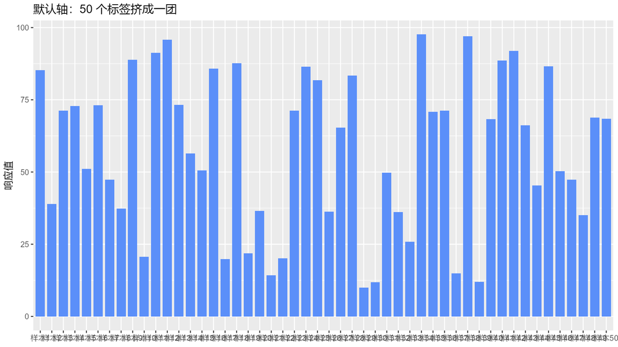

50 个分类水平时 ggplot2 的默认 x 轴：标签互相重叠，完全无法阅读

```r
ggplot(df50, aes(x = sample, y = value)) +
  geom_col(fill = "#5B8FF9", width = 0.8) +
  labs(x = NULL, y = "响应值", title = "默认轴：50 个标签挤成一团") +
  theme_grey(base_size = 12)
```

`ggutils` 提供 `guide_axis_smart()`：它接管分类轴标签的绘制，做三件事——

1. **只显示你关心的那部分标签**（`which =` / `n =`），其余的用**引导线（leader line）**连回各自的刻度，位置关系一目了然；
2. **把标签在轴外侧分成多行（x 轴）或多列（y 轴）错开**，把页面上原本浪费的空白用起来；
3. **保证任何情况下标签都不互相重叠**：实在放不下时宁可少显示几个，也不会画成一团。

# 快速开始

在原来的图上加一行 `guides()` 就行：

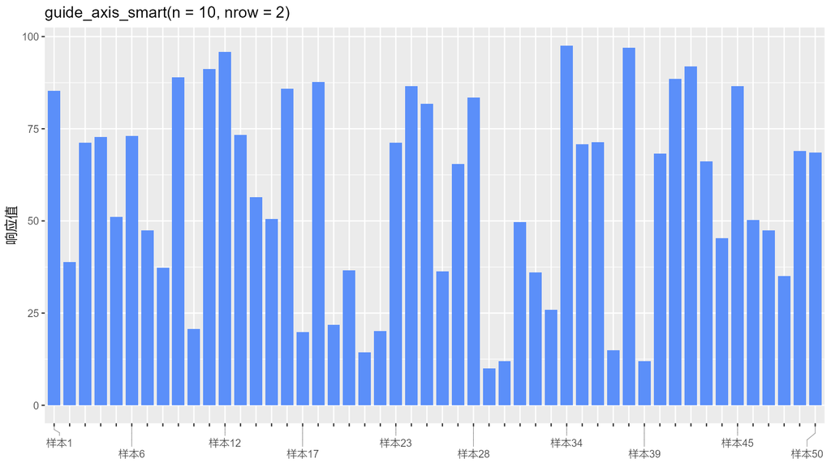

guide_axis_smart(n = 10, nrow = 2)：只显示 10 个标签，分两行错开，引导线连回各自刻度

```r
ggplot(df50, aes(x = sample, y = value)) +
  geom_col(fill = "#5B8FF9", width = 0.8) +
  guides(x = guide_axis_smart(n = 10, nrow = 2)) +
  labs(x = NULL, y = "响应值", title = "guide_axis_smart(n = 10, nrow = 2)") +
  theme_grey(base_size = 12)
```

只改了三处：加载包、`guides(x = guide_axis_smart(...))`、其他照旧。注意**不需要**再写 `theme(axis.text.x = element_blank())`，标签的绘制已经完全交给 guide 了。

## 两种挂载方式

`guide_axis_smart()` 既可以放在 `guides()` 里，也可以作为 scale 的 `guide` 参数（在 `coord_flip()` 下二者不等价，见后文）：

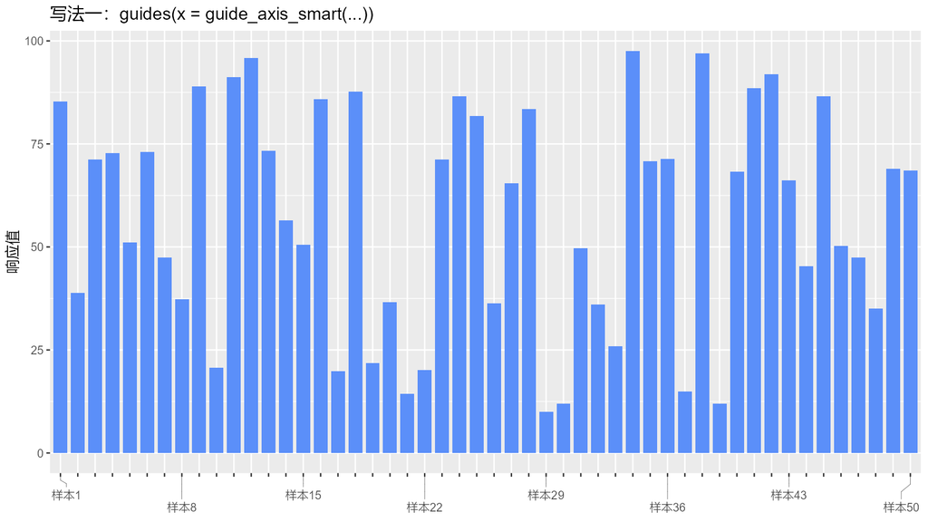

两种写法效果相同：guides(x = …)（上图）与 scale_x_discrete(guide = …)（下图）

```r
p_guides <- ggplot(df50, aes(x = sample, y = value)) +
  geom_col(fill = "#5B8FF9", width = 0.8) +
  guides(x = guide_axis_smart(n = 8, nrow = 2)) +
  labs(x = NULL, y = "响应值", title = "写法一：guides(x = guide_axis_smart(...))") +
  theme_grey(base_size = 12)

p_scale <- ggplot(df50, aes(x = sample, y = value)) +
  geom_col(fill = "#5B8FF9", width = 0.8) +
  scale_x_discrete(guide = guide_axis_smart(n = 8, nrow = 2)) +
  labs(x = NULL, y = "响应值", title = "写法二：scale_x_discrete(guide = ...)") +
  theme_grey(base_size = 12)

p_guides
```

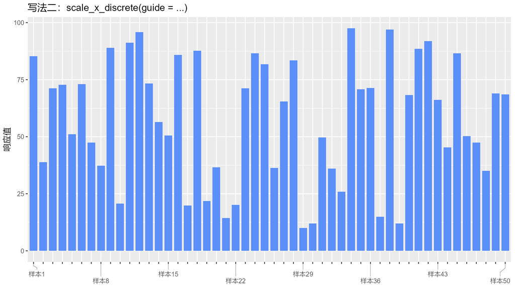

两种写法效果相同：guides(x = …)（上图）与 scale_x_discrete(guide = …)（下图）

```r
p_scale
```

# 参数一览：每个参数是干什么的

`guide_axis_smart()` 的参数分四类：**选哪些标签**、**标签怎么排**、**引导线怎么画**、 **其余透传给 `guide_axis()`**。日常改得最多的只有五个：`which`、`n`、`nrow`、 `connection_style`、`angle`，其余保持默认即可。

| 参数 | 默认值 | 含义 |
| --- | --- | --- |
| **选哪些标签** |  |  |
| `which` | `NULL` | 显示哪些标签。整数下标 / 字符标签 / 逻辑向量 / 函数四种写法，`NULL` 表示”放得下多少显示多少” |
| `n` | `NULL` | 最多显示几个。`which = NULL` 时等距挑 `n` 个；给了 `which` 则把选区再截到 `n` 个 |
| **标签怎么排** |  |  |
| `nrow` | `NULL` | 并行轨道数（x 轴是行，y 轴是列）。`NULL` 为自动：一行放得下就一行，挤在一起才分层 |
| `padding` | `0.25` | 同一轨道内两个标签之间的最小间隙，单位是”标签高度的倍数”；环形轴上是沿弧的间隙 |
| `gap` | `0.30` | 两条轨道之间的间隙（相对标签高度） |
| `extend` | `0` | 允许标签越过轴范围的比例（0 到 0.5）。默认 `0` 保证标签不被面板裁掉；调大需配合足够的 `plot.margin` |
| `panel_width` | `NULL` | 预估计轨道数时假设的面板宽度（x 轴）或高度（y 轴），单位 cm；`NULL` 按设备尺寸估算 |
| `max_nrow` | `8L` | 自动分行时轨道数的上限 |
| **引导线** |  |  |
| `connection` | `TRUE` | 是否画引导线 |
| `connection_style` | `"diagonal"` | 线的形状：`"diagonal"` 短垂线→斜线→短垂线（circlize / `anno_mark()` 同款）、`"straight"` 一条直线、`"elbow"` 垂直段加台阶 |
| `link_length` | `3` | 轴线到第一行（列）标签的连线长度，单位 mm；环形轴上是圆到标签的距离 |
| `connection_col` | `NULL` | 引导线颜色，`NULL` 时取刻度线的颜色 |
| `connection_lwd` | `0.5` | 引导线粗细 |
| `connection_lty` | `1` | 引导线线型 |
| **刻度与文字** |  |  |
| `tick` | `"all"` | 刻度线画哪些：`"all"` 全画、`"shown"` 只画有标签的、`"none"` 不画 |
| `angle` | `NULL` | 标签旋转角度（0/45/90…）；`NULL` 继承主题 |
| `hjust`, `vjust` | `NULL` | 标签在自己盒子内的对齐方式；`NULL` 居中（居中时引导线才对准文字视觉中心） |
| **环形坐标专用** |  |  |
| `theta_side` | `"outside"` | 标签放圆外 `"outside"`，还是贴住 `coord_radial(inner.radius =)` 的内圈 `"inside"` |
| **透传给 `guide_axis()`** |  |  |
| `title` | `waiver()` | 轴标题 |
| `minor.ticks` | `FALSE` | 是否画次刻度 |
| `cap` | `"none"` | 轴线末端样式 |
| `order` | `0` | 多个 guide 时的绘制顺序 |
| `position` | `waiver()` | 轴的位置（top/bottom/left/right），一般不用改 |
| `theme` | `NULL` | 只作用于这个 guide 的主题元素 |

几个常见组合，直接抄：

```r
# 200 个基因里只标 8 个，一行
guides(y = guide_axis_smart(which = c("TP53", "EGFR", "MYC", "KRAS",
                                      "BRCA1", "PTEN", "RB1", "ALK")))

# 50 个样本，最多标 10 个，分两行错开
guides(x = guide_axis_smart(n = 10, nrow = 2))

# 标签很长、挤在一起：分层 + 斜线引导，线再长一点
guides(x = guide_axis_smart(which = 1:40, nrow = 3,
                            connection_style = "diagonal", link_length = 5))

# 环形热图：标签放圆外，只标 20 个基因
guides(theta = guide_axis_smart(which = mark, theta_side = "outside"))
```

# 只显示指定标签：`which` 的四种写法

`which` 决定”显示哪些标签”，可以接受四种形式：

| 写法 | 含义 | 示例 |
| --- | --- | --- |
| 整数向量 | 在 scale 的 breaks 顺序里的下标 | `which = seq(1, 50, by = 10)` |
| 字符向量 | 按标签文本精确匹配 | `which = c("样本1", "样本25", "样本50")` |
| 逻辑向量 | 与标签一一对应，`TRUE` 的显示 | `which = grepl("0$", levels(sample))` |
| 函数 | `function(labels, positions)` 返回逻辑向量 | `which = function(labels, positions) positions > 0.45 & positions < 0.55` |

其中 `positions` 是该标签在面板内的**相对坐标**（0 到 1，沿轴方向），和具体的数据值无关，写位置规则时很好用。

## 整数下标

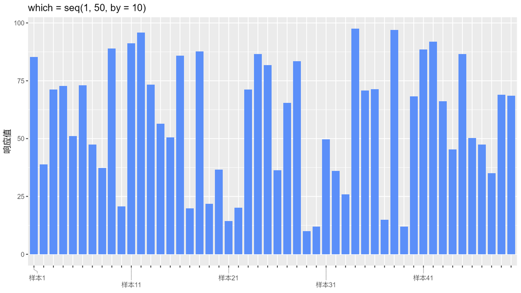

which = seq(1, 50, by = 10)：每 10 个显示一个

```r
ggplot(df50, aes(x = sample, y = value)) +
  geom_col(fill = "#5B8FF9", width = 0.8) +
  guides(x = guide_axis_smart(which = seq(1, 50, by = 10), nrow = 2)) +
  labs(x = NULL, y = "响应值", title = "which = seq(1, 50, by = 10)") +
  theme_grey(base_size = 12)
```

## 字符向量

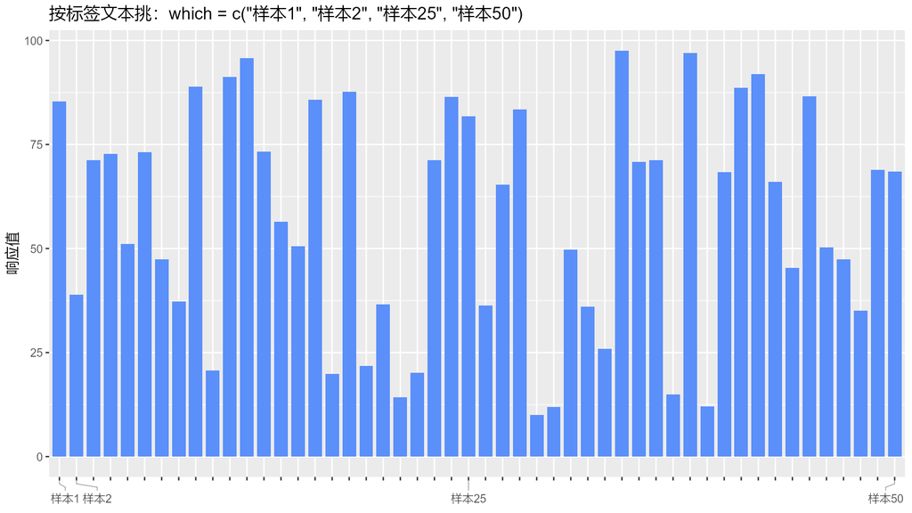

按标签文本挑：显示 样本1、样本2、样本25、样本50 这四个标签

```r
ggplot(df50, aes(x = sample, y = value)) +
  geom_col(fill = "#5B8FF9", width = 0.8) +
  guides(x = guide_axis_smart(
    which = c("样本1", "样本2", "样本25", "样本50"),
    nrow = 1
  )) +
  labs(x = NULL, y = "响应值", title = "按标签文本挑：which = c(\"样本1\", \"样本2\", \"样本25\", \"样本50\")") +
  theme_grey(base_size = 12)
```

## 逻辑向量

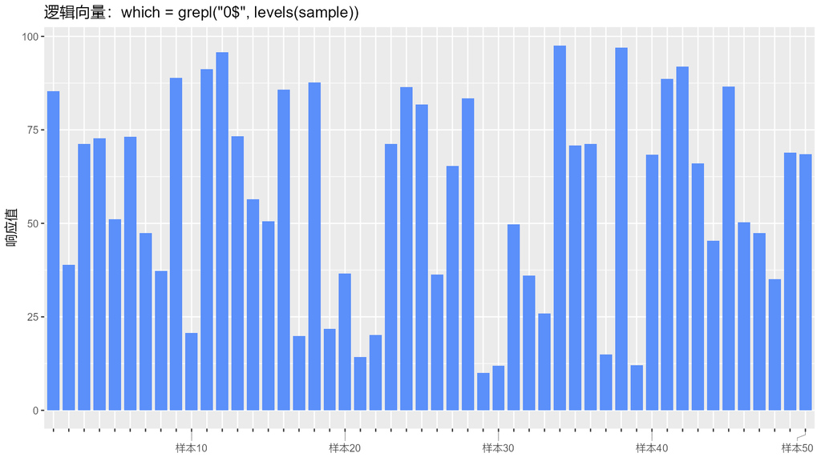

逻辑向量挑选：只显示编号以 0 结尾的样本

```r
ggplot(df50, aes(x = sample, y = value)) +
  geom_col(fill = "#5B8FF9", width = 0.8) +
  guides(x = guide_axis_smart(
    which = grepl("0$", levels(df50$sample)),
    nrow = 1
  )) +
  labs(x = NULL, y = "响应值", title = "逻辑向量：which = grepl(\"0$\", levels(sample))") +
  theme_grey(base_size = 12)
```

## 函数

`which` 用函数时，会在拿到标签文本和相对位置后调用它，返回逻辑向量（也可以返回下标向量）。下面只显示每 10 个中的第一个：

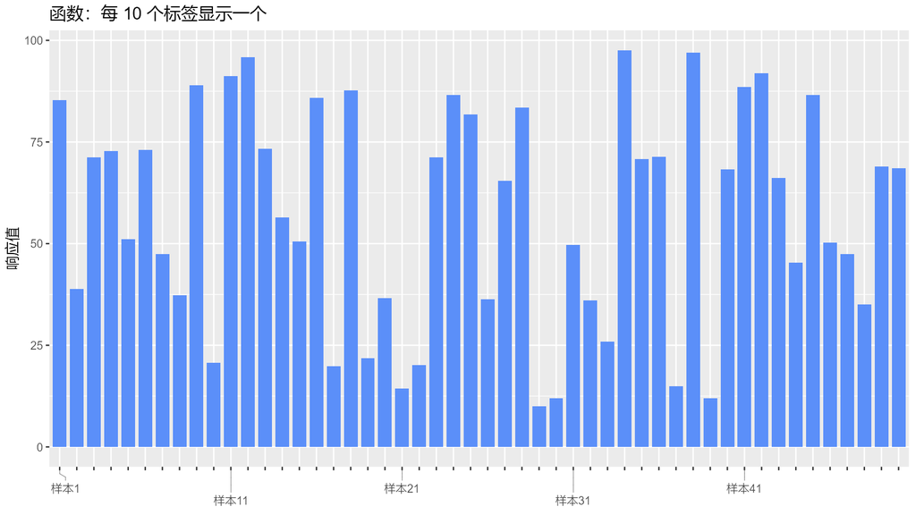

which = function(labels, positions) seq_along(labels) %% 10 == 1：每 10 个显示一个

```r
ggplot(df50, aes(x = sample, y = value)) +
  geom_col(fill = "#5B8FF9", width = 0.8) +
  guides(x = guide_axis_smart(
    which = function(labels, positions) seq_along(labels) %% 10 == 1,
    nrow = 2
  )) +
  labs(x = NULL, y = "响应值", title = "函数：每 10 个标签显示一个") +
  theme_grey(base_size = 12)
```

函数形式的典型用途是按**位置**挑：`positions` 是 0 到 1 的相对坐标，比如 `positions > 0.9` 只保留轴末端的标签。

# 自动挑选：`n`

不想自己算下标时，直接告诉 guide “最多显示几个”：

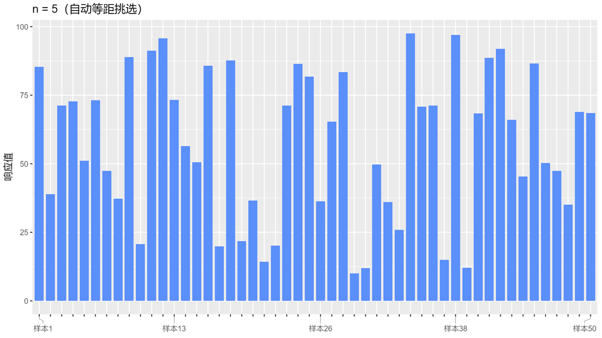

n = 5：自动等距挑 5 个标签，一行就放得下

```r
ggplot(df50, aes(x = sample, y = value)) +
  geom_col(fill = "#5B8FF9", width = 0.8) +
  guides(x = guide_axis_smart(n = 5)) +
  labs(x = NULL, y = "响应值", title = "n = 5（自动等距挑选）") +
  theme_grey(base_size = 12)
```

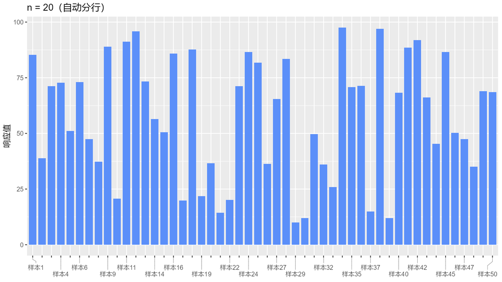

n = 20：挑 20 个标签，一行放不下时自动分成两行

```r
ggplot(df50, aes(x = sample, y = value)) +
  geom_col(fill = "#5B8FF9", width = 0.8) +
  guides(x = guide_axis_smart(n = 20)) +
  labs(x = NULL, y = "响应值", title = "n = 20（自动分行）") +
  theme_grey(base_size = 12)
```

`n` 与 `which` 同时给出时，先由 `which` 选出集合，`n` 再把**结果**等距截断为最多 `n` 个（`n` 是硬上限）；`which = NULL` 时 `n` 直接从全部标签里等距挑。

## 自动行为：什么都不填会怎样

**轨道数（行数/列数）的自动策略**：能一行放下就一行——标签沿轴摊开，引导线短、最接近 `anno_mark()` 的观感；只有全部标签总宽度超过一行可用宽度时才会分行。若标签集中挤在轴的一小段里，即使总宽度不大，也会按这一簇的跨度自动分成多行，避免长斜线交叉。轨道数最多 `max_nrow` 条（默认 `8`）。

`which = NULL` 且 `n = NULL` 时，guide 默认显示**全部**标签。如果全部标签总宽度超过了 `max_nrow` 条轨道能容纳的范围，guide 会自动等距抽稀，并通过 `cli` 给出**一次**提示，例如：

```
#> ℹ Only 123 of 200 labels fit into 8 tracks; 77 labels are not displayed.
#> ℹ Set `nrow` or `which` in `guide_axis_smart()` to control this.
```

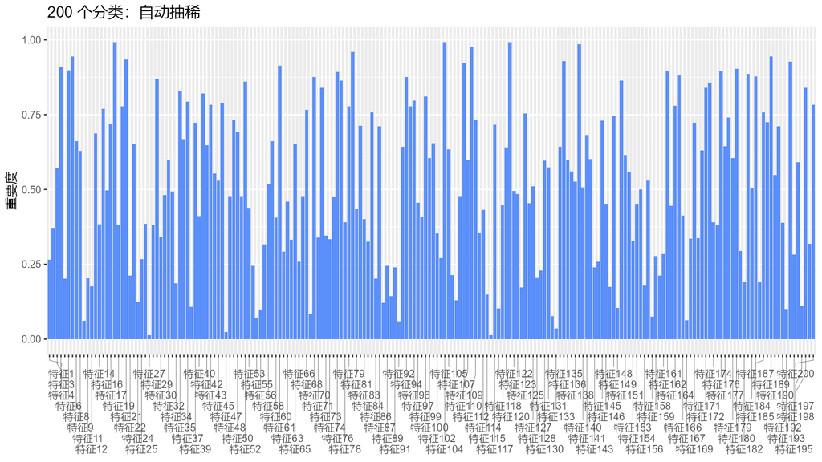

200 个分类、不指定 which/n：自动抽稀后仍然清晰，但会少显示标签

```r
set.seed(1)
df200 <- data.frame(
  feature = factor(paste0("特征", 1:200), levels = paste0("特征", 1:200)),
  value = runif(200)
)

ggplot(df200, aes(x = feature, y = value)) +
  geom_col(fill = "#5B8FF9", width = 0.9) +
  guides(x = guide_axis_smart()) +
  labs(x = NULL, y = "重要度", title = "200 个分类：自动抽稀") +
  theme_grey(base_size = 12)
```

如果不想看到提示（比如在循环里批量出图），设置 `options(ggutils.quiet = TRUE)` 即可静音；但**永远建议显式写 `n =` 或 `which =`**，让显示哪些标签由你决定，而不是由屏幕尺寸决定。

# 多行错开：`nrow`、`gap`、`padding`

x 轴标签在轴下方占几行，由 `nrow` 控制；`NULL`（默认）表示自动——**能一行放下就一行**，挤在一段里或总宽超了才分行。`gap` 是行间距（默认 `0.30`），`padding` 是同一行里相邻标签盒之间的最小间距（默认 `0.25`），两者都是**相对标签高度**的比例。

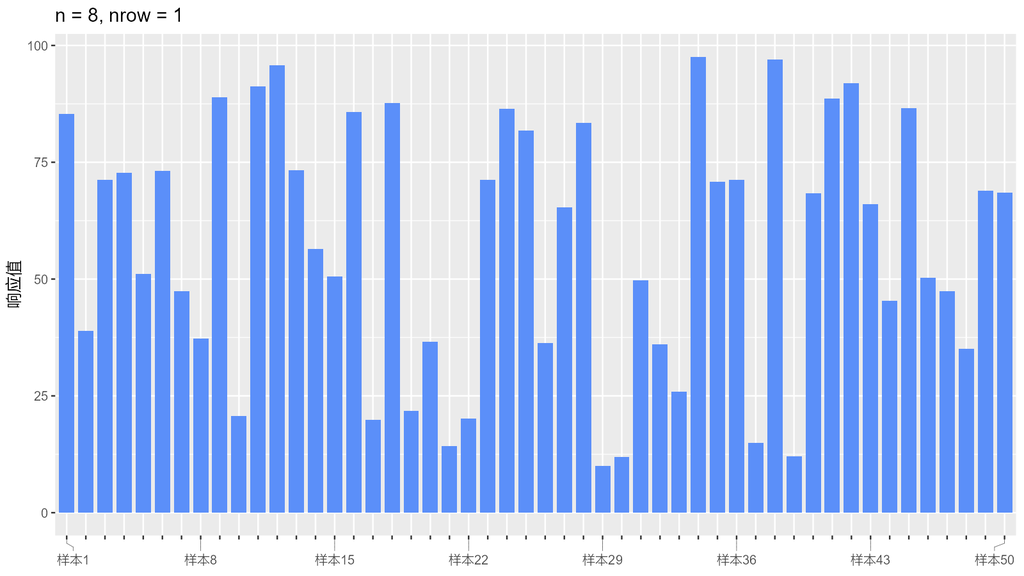

nrow = 1：一行展示，标签必须挤得下

```r
ggplot(df50, aes(x = sample, y = value)) +
  geom_col(fill = "#5B8FF9", width = 0.8) +
  guides(x = guide_axis_smart(n = 8, nrow = 1)) +
  labs(x = NULL, y = "响应值", title = "n = 8, nrow = 1") +
  theme_grey(base_size = 12)
```

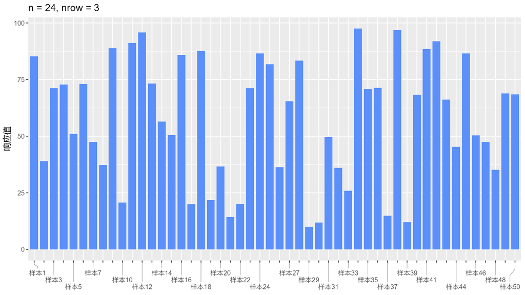

nrow = 3：三行错开，纵向空间用得越充分，能显示的标签就越多

```r
ggplot(df50, aes(x = sample, y = value)) +
  geom_col(fill = "#5B8FF9", width = 0.8) +
  guides(x = guide_axis_smart(n = 24, nrow = 3)) +
  labs(x = NULL, y = "响应值", title = "n = 24, nrow = 3") +
  theme_grey(base_size = 12)
```

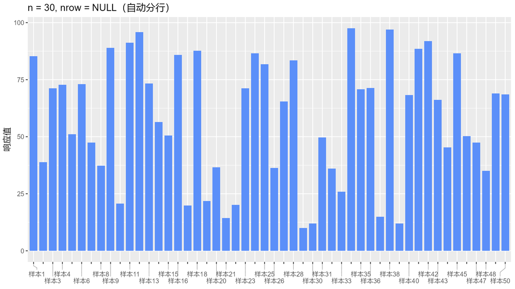

nrow = NULL：能一行放下就一行，放不下才自动分行

```r
ggplot(df50, aes(x = sample, y = value)) +
  geom_col(fill = "#5B8FF9", width = 0.8) +
  guides(x = guide_axis_smart(n = 30)) +
  labs(x = NULL, y = "响应值", title = "n = 30, nrow = NULL（自动分行）") +
  theme_grey(base_size = 12)
```

调参口诀：

- **想多显示标签**：加 `nrow`（纵轴是 y 轴时是加列数，见下一节）；
- **标签行看着太挤**：调大 `gap`、`padding`（比如 `gap = 0.4`）；
- **标签在画布边缘被裁掉**：默认 `extend = 0` 已经保证标签盒不越出面板，通常不会发生；只有在你显式把 `extend` 调大（换取更宽松的排布）时，才需要同时给 `theme(plot.margin = ...)` 留出边距。

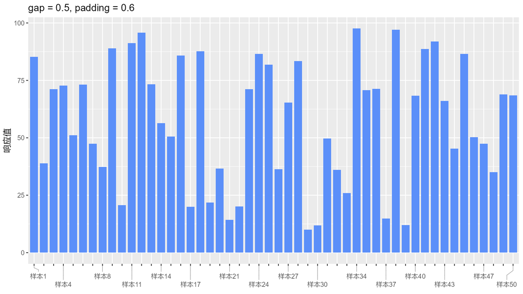

gap = 0.5, padding = 0.6：行距和盒间距都放宽

```r
ggplot(df50, aes(x = sample, y = value)) +
  geom_col(fill = "#5B8FF9", width = 0.8) +
  guides(x = guide_axis_smart(n = 16, nrow = 2, gap = 0.5, padding = 0.6)) +
  labs(x = NULL, y = "响应值", title = "gap = 0.5, padding = 0.6") +
  theme_grey(base_size = 12)
```

# 引导线：`connection_style` 与 `link_length`

只要标签被”挪动”过（位置和刻度不一致），guide 默认就会画引导线（`connection = TRUE`）。`connection_style` 有三种：

- `"diagonal"`（默认）：轴外先画一小段垂直于轴的短线，再一条斜线连到标签所在行，最后再一小段垂直短线收尾。这是 `circlize` 和 `ComplexHeatmap::anno_mark()` 的经典几何，多行错开时最清楚；
- `"straight"`：从刻度一条斜直线直接连到标签盒；
- `"elbow"`：垂直段 + 一段平行于轴的台阶，横平竖直。

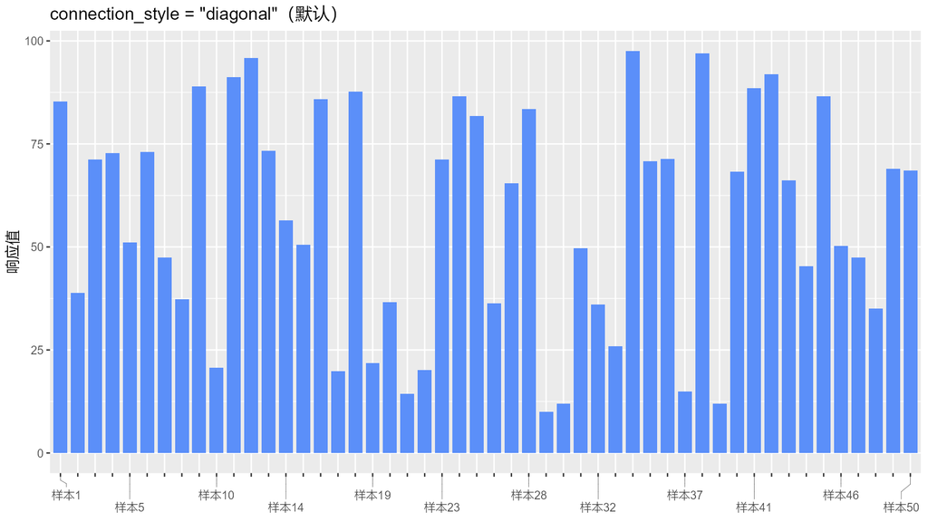

connection_style 取 diagonal（默认）：短垂线 + 斜线 + 短垂线

```r
ggplot(df50, aes(x = sample, y = value)) +
  geom_col(fill = "#5B8FF9", width = 0.8) +
  guides(x = guide_axis_smart(n = 12, nrow = 2)) +
  labs(x = NULL, y = "响应值", title = "connection_style = \"diagonal\"（默认）") +
  theme_grey(base_size = 12)
```

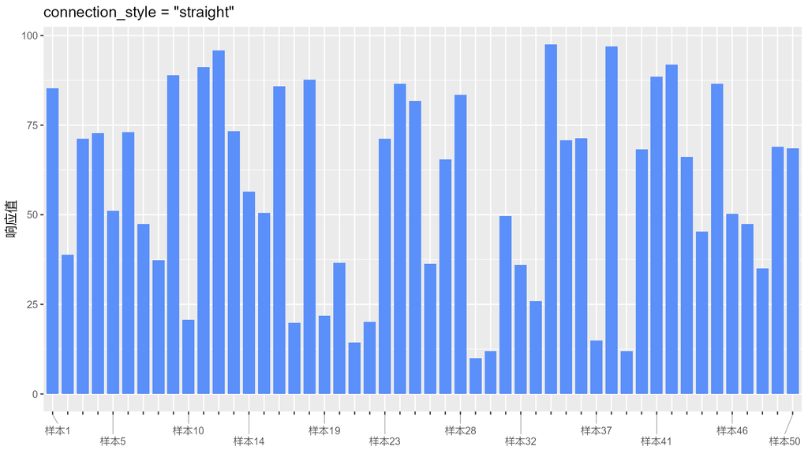

connection_style 取 straight：一条斜直线

```r
ggplot(df50, aes(x = sample, y = value)) +
  geom_col(fill = "#5B8FF9", width = 0.8) +
  guides(x = guide_axis_smart(n = 12, nrow = 2, connection_style = "straight")) +
  labs(x = NULL, y = "响应值", title = "connection_style = \"straight\"") +
  theme_grey(base_size = 12)
```

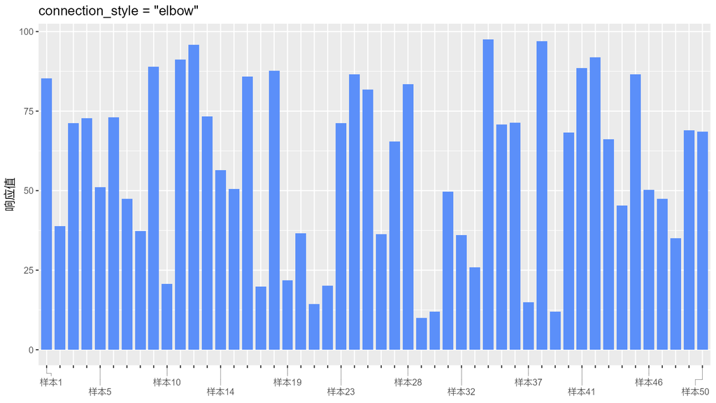

connection_style 取 elbow：垂直段 + 平行于轴的台阶

```r
ggplot(df50, aes(x = sample, y = value)) +
  geom_col(fill = "#5B8FF9", width = 0.8) +
  guides(x = guide_axis_smart(n = 12, nrow = 2, connection_style = "elbow")) +
  labs(x = NULL, y = "响应值", title = "connection_style = \"elbow\"") +
  theme_grey(base_size = 12)
```

`link_length`（默认 `3`，单位毫米）控制”轴线到第一行（列）标签之间那段连线”的长度：行数多、线密的时候调小一点更紧凑，想让引导线更舒展就调大。

线的颜色、粗细、线型分别由 `connection_col`、`connection_lwd`（默认 `0.5`）、`connection_lty` 控制；`connection_col = NULL`（默认）时使用刻度线的颜色。不需要引导线时设 `connection = FALSE`。

## 刻度线：`tick`

`tick` 控制贴着轴线的刻度短线：

- `"all"`（默认）：所有刻度都画，保留”这里还有别的类别”的信息；
- `"shown"`：只给显示出来的标签画刻度，画面更干净；
- `"none"`：完全不画刻度。

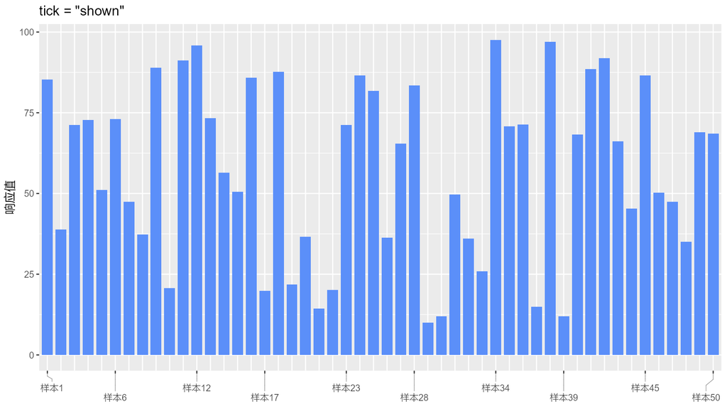

tick 取 shown：只给显示出来的标签画刻度

```r
ggplot(df50, aes(x = sample, y = value)) +
  geom_col(fill = "#5B8FF9", width = 0.8) +
  guides(x = guide_axis_smart(n = 10, nrow = 2, tick = "shown")) +
  labs(x = NULL, y = "响应值", title = "tick = \"shown\"") +
  theme_grey(base_size = 12)
```

# y 轴（水平分类轴）

把分类变量映射到 y 轴即可。注意 **`nrow` 在 y 轴上表示”列数”**：标签会在轴外侧分成若干列错开，越靠外的列装的是”被推出去”的标签。

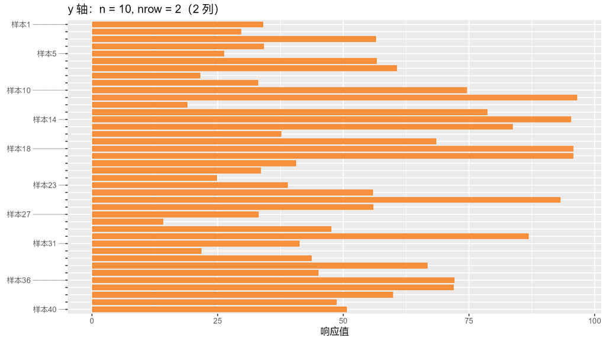

y 轴：nrow = 2 表示标签分成 2 列错开

```r
labs40 <- paste0("样本", 1:40)
df40 <- data.frame(
  sample = factor(labs40, levels = rev(labs40)),
  value = round(runif(40, 10, 100), 1)
)

ggplot(df40, aes(x = value, y = sample)) +
  geom_col(fill = "#F6903D", width = 0.8) +
  guides(y = guide_axis_smart(n = 10, nrow = 2)) +
  labs(x = "响应值", y = NULL, title = "y 轴：n = 10, nrow = 2（2 列）") +
  theme_grey(base_size = 12)
```

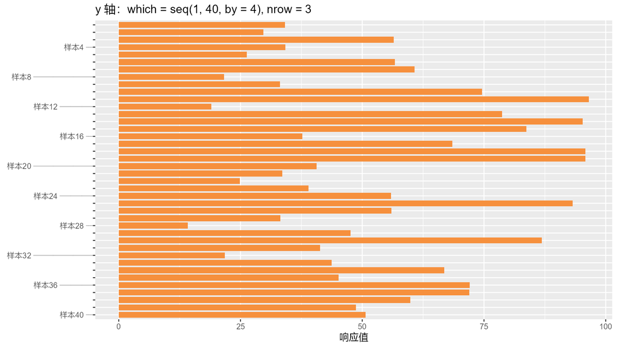

y 轴：nrow = 3，三列错开可以显示更多标签

```r
ggplot(df40, aes(x = value, y = sample)) +
  geom_col(fill = "#F6903D", width = 0.8) +
  guides(y = guide_axis_smart(which = seq(1, 40, by = 4), nrow = 3)) +
  labs(x = "响应值", y = NULL, title = "y 轴：which = seq(1, 40, by = 4), nrow = 3") +
  theme_grey(base_size = 12)
```

# 环形坐标：`coord_radial()`

`coord_radial()` 把位置标度改名为 `theta` 和 `r`，guide 要挂在 `guides(theta = ...)` 上。 `ggutils` 会把标签按 `circlize::circos.labels()` 的方式排布：文字沿半径、朝向圆心， 左半边自动翻转避免倒置；拥挤时用 `smartAlign` 沿弧向匀开，并用三段引导线 （径向短线 → 斜线 → 径向短线）连回各自刻度。

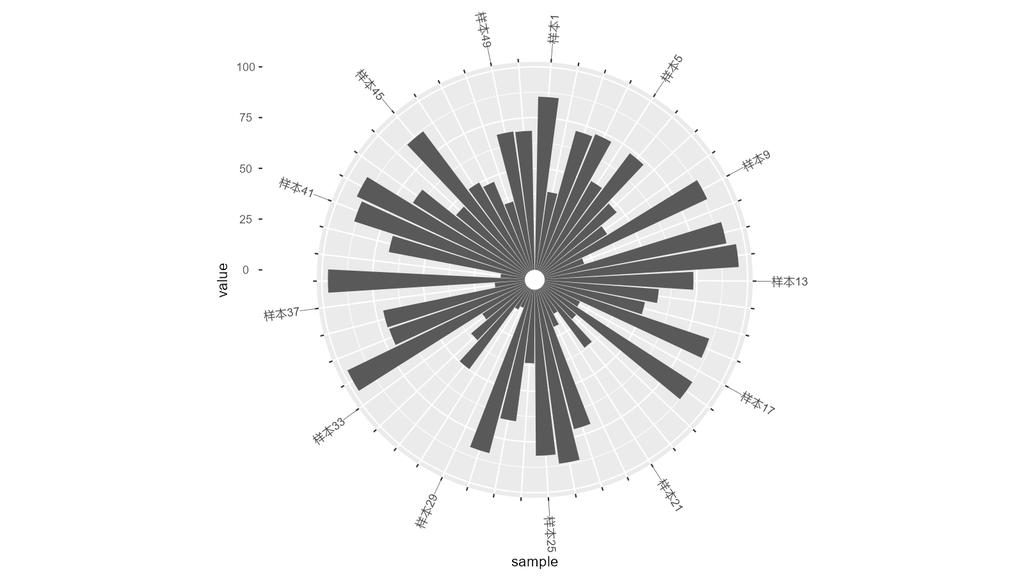

coord_radial(theta = ‘x’)：环形条形图，每 4 个显示一个标签

```r
ggplot(df50, aes(sample, value)) +
  geom_col() +
  coord_radial(theta = "x") +
  guides(theta = guide_axis_smart(which = seq(1, 50, by = 4)))
```

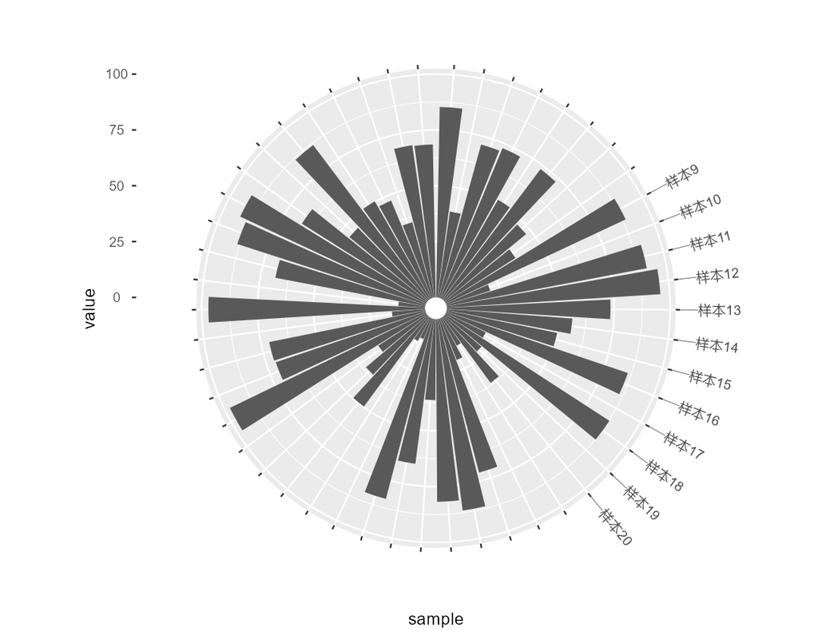

拥挤的 12 个标签：沿弧匀开，三段引导线连回刻度

```r
ggplot(df50, aes(sample, value)) +
  geom_col() +
  coord_radial(theta = "x") +
  guides(theta = guide_axis_smart(which = 9:20))
```

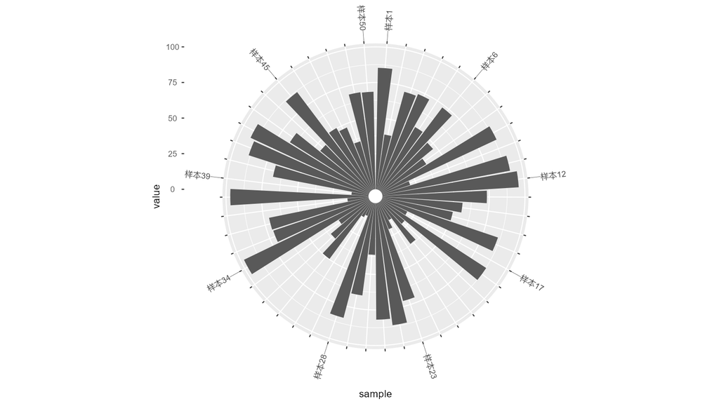

分类变量映射到 y 轴、theta = ‘y’ 时同样工作

```r
ggplot(df50, aes(value, sample)) +
  geom_col() +
  coord_radial(theta = "y") +
  guides(theta = guide_axis_smart(n = 10))
```

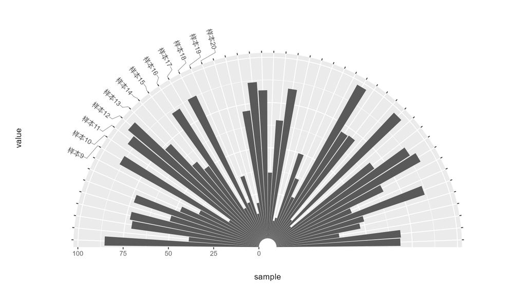

半圆（start/end）：只画一段弧也能正常排布

```r
ggplot(df50, aes(sample, value)) +
  geom_col() +
  coord_radial(theta = "x", start = -0.5 * pi, end = 0.5 * pi) +
  guides(theta = guide_axis_smart(which = 9:20))
```

## 环形热图：标签放外侧还是内侧

内置数据（300 基因 × 8 样本）画成环形热图时，`theta` 轴就是基因方向：

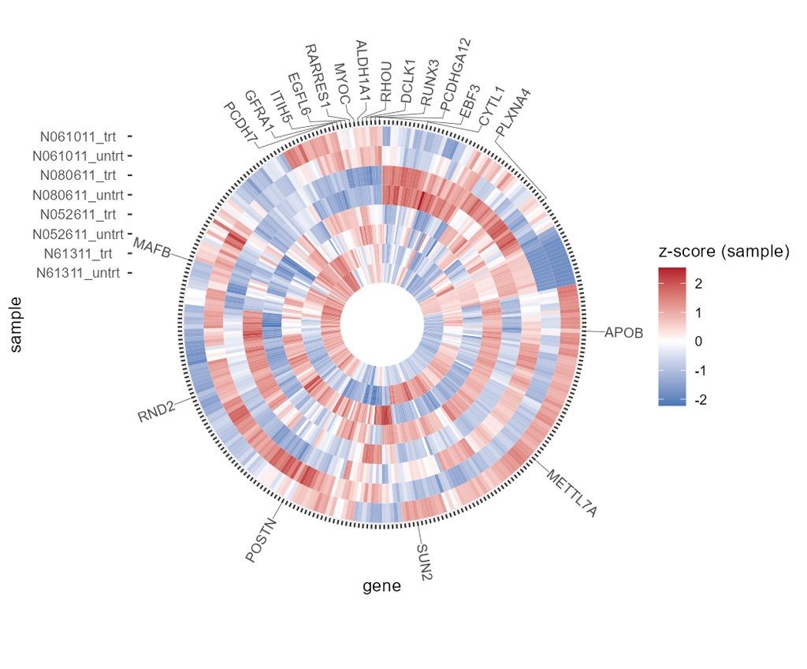

环形热图，标签在外侧：拥挤的基因簇沿外圈匀开

```r
data(airway_heatmap)
ggplot(airway_sample_z, aes(gene, sample, fill = z_sample)) +
  geom_tile() +
  coord_radial(theta = "x", inner.radius = 0.2) +
  guides(theta = guide_axis_smart(which = airway_heatmap$mark)) +
  scale_fill_gradient2(low = "#2166ac", mid = "white", high = "#b2182b",
                       midpoint = 0, name = "z-score (sample)")
```

内圈半径更大时可以把标签放进洞里（`theta_side = "inside"`），标签贴在内圈边界上：

```
#> Only 18 of 20 labels fit around the ring; 2 were dropped. Use `which` / `n` or
#> a larger device.
```

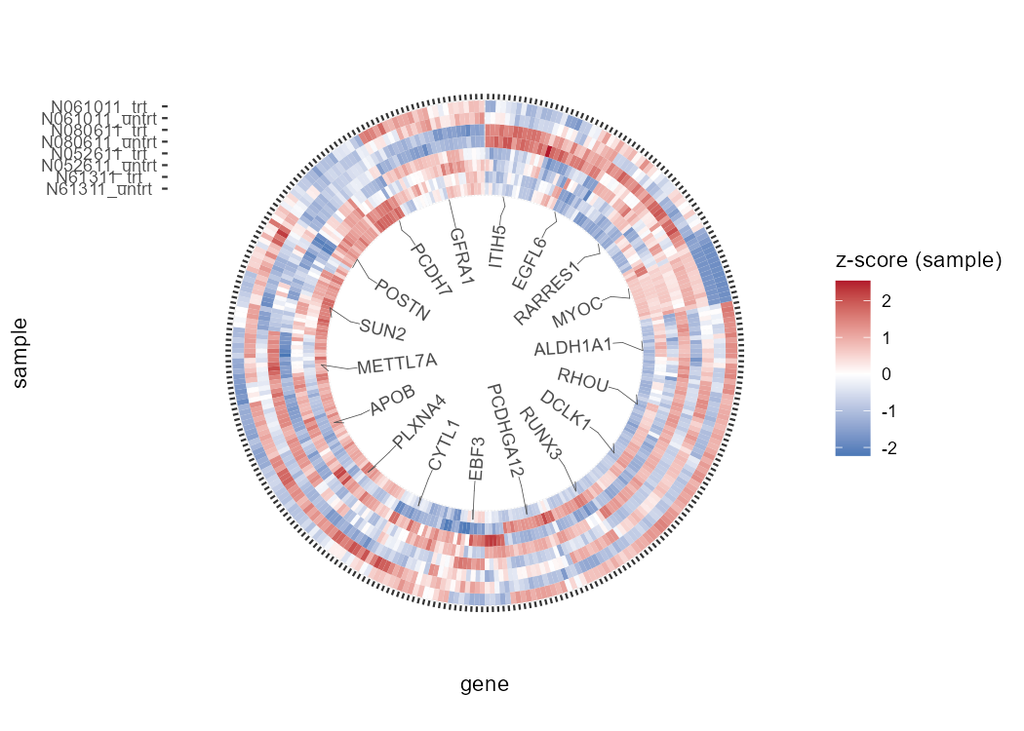

环形热图，标签在内侧：theta_side = ‘inside’，标签贴内半径

```r
ggplot(airway_sample_z, aes(gene, sample, fill = z_sample)) +
  geom_tile() +
  coord_radial(theta = "x", inner.radius = 0.62) +
  guides(theta = guide_axis_smart(
    which = airway_heatmap$mark, theta_side = "inside"
  )) +
  scale_fill_gradient2(low = "#2166ac", mid = "white", high = "#b2182b",
                       midpoint = 0, name = "z-score (sample)")
```

## 分面：每个面板一个圆

`facet_wrap()` / `facet_grid()` 下每个面板都是独立的圆，标签各自排布：

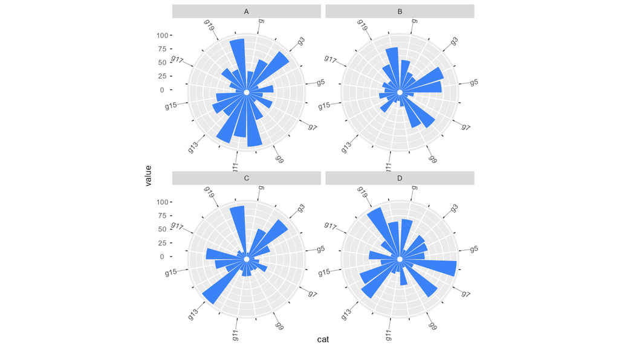

facet_wrap + coord_radial：每个面板一个圆，每 2 个显示一个标签

```r
d_facet <- data.frame(
  panel = rep(c("A", "B", "C", "D"), each = 20),
  cat   = factor(rep(paste0("g", 1:20), 4), levels = paste0("g", 1:20)),
  value = round(runif(80, 5, 100), 1)
)
ggplot(d_facet, aes(cat, value)) +
  geom_col(fill = "#3b82f6") +
  coord_radial(theta = "x") +
  guides(theta = guide_axis_smart(which = seq(1, 20, by = 2))) +
  facet_wrap(~panel)
```

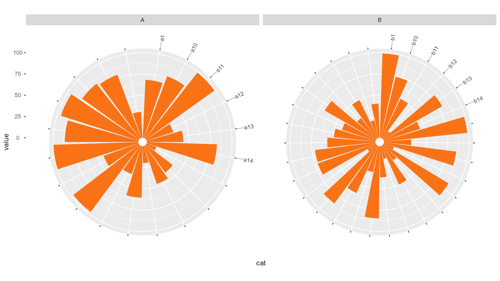

facet_wrap + free_x：每个面板只标自己的前 6 个标签

```r
d_free <- data.frame(
  panel = c(rep("A", 20), rep("B", 30)),
  cat   = factor(c(paste0("a", 1:20), paste0("b", 1:30))),
  value = round(runif(50, 5, 100), 1)
)
ggplot(d_free, aes(cat, value)) +
  geom_col(fill = "#f97316") +
  coord_radial(theta = "x") +
  guides(theta = guide_axis_smart(which = 1:6)) +
  facet_wrap(~panel, scales = "free_x")
```

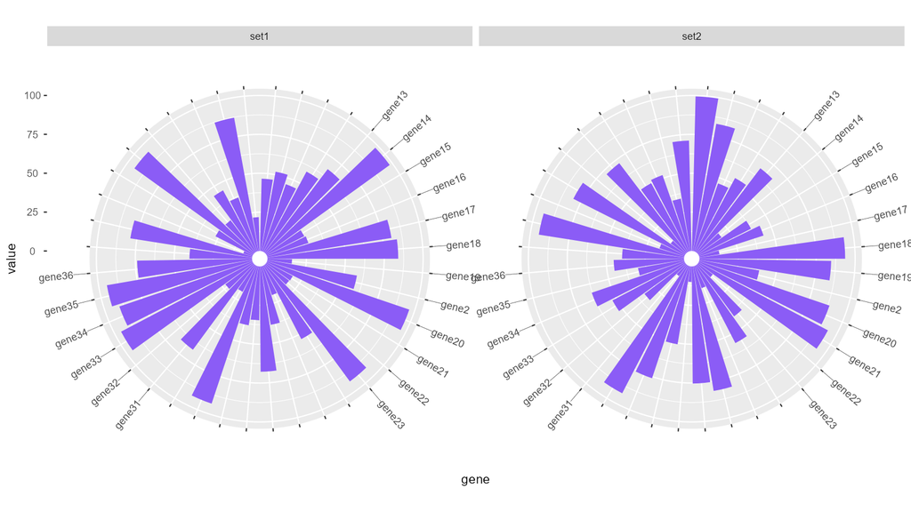

每个面板里都有一簇拥挤标签：各自沿弧匀开，互不影响

```r
d_crowd <- data.frame(
  panel = rep(c("set1", "set2"), each = 40),
  gene  = factor(rep(paste0("gene", 1:40), 2)),
  value = round(runif(80, 5, 100), 1)
)
ggplot(d_crowd, aes(gene, value)) +
  geom_col(fill = "#8b5cf6") +
  coord_radial(theta = "x") +
  guides(theta = guide_axis_smart(which = c(5:16, 25:30))) +
  facet_wrap(~panel)
```

分面环形热图要加 `scales = "free_x"`：每个面板用自己的基因标度，圆环才完整，标签也只落在本面板包含的基因上：

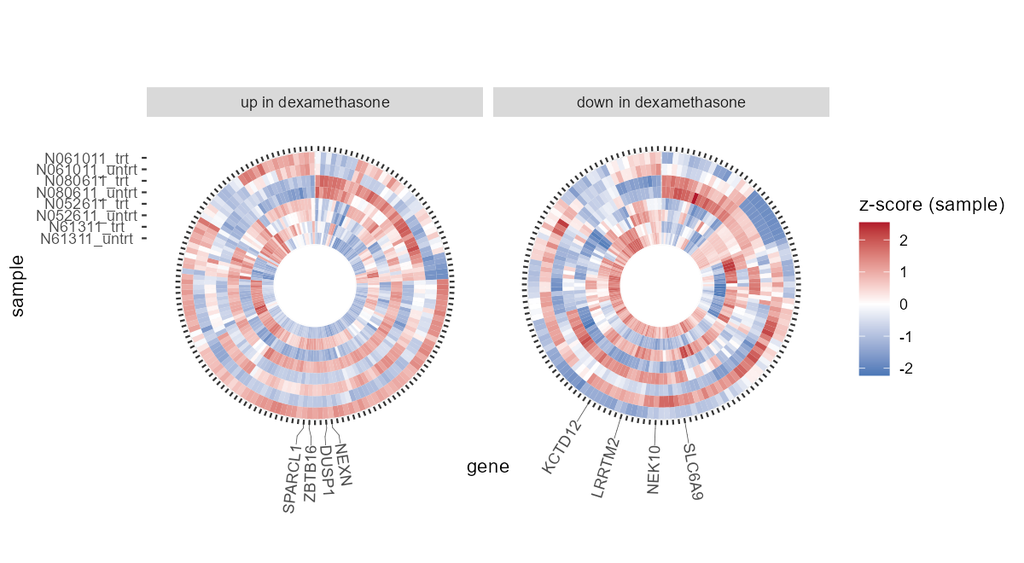

分面环形热图 + free_x：每个面板圆环完整，只标自己包含的 4 个基因

```r
ggplot(airway_sample_z, aes(gene, sample, fill = z_sample)) +
  geom_tile() +
  coord_radial(theta = "x", inner.radius = 0.3) +
  guides(theta = guide_axis_smart(which = unlist(airway_heatmap$mark_by_set))) +
  facet_wrap(~gene_set, ncol = 2, scales = "free_x") +
  scale_fill_gradient2(low = "#2166ac", mid = "white", high = "#b2182b",
                       midpoint = 0, name = "z-score (sample)")
```

> 提示：不加 `scales = "free_x"` 时各面板共享同一个 `theta` 标度，会留下一半空位， 而且 `which` 选中的 8 个基因会在两个面板都画标签；分面环形热图记得写 `free_x`。

环形坐标的标签同样继承主题的轴标签样式（`axis.text.x` / `axis.text.y`，包括大小、颜色、 字体等），和普通坐标轴一致。